# Datenverarbeitung

Regina Arocha, Elias Böni, Kevin Elliott, Manuela Huber, Fabian Schmid

31 Mai 2019

## Beschreibung

In diesem Dokument werden die beschaffenen Daten weiter bearbeitet und ausgewertet.

## Twitter Daten

### Vorbereitung

Für die Ausführung von diesem Skript sollte man den Ordner “03_Datenverarbeitung” lokal speichern.

Die Spalte “tweets” vom Outputfile “twitter_complete_v1.xlsx”, welches vom R-Skript “Datenbeschaffung” stammt, wurde anhand im Excel anhand der Formel *=GOOGLETRANSLATE(Posts;DETECTLANGUAGE(Posts);“en”)* für die spätere Sentimentsanalyse übersetzt. Die Übersetzung wurde in einer neuen Spalte “tweets_English” eingefügt.

```r
# Working Directory setzen (Speicherort vom Ordner)
setwd("~/01_Master/023_Technology & Market Intelligence/04_Daten")

# Daten einlesen
library(readxl)
twitter <- read_excel("twitter_complete_v2.xlsx")
```

In einem nächsten Schritt werden die Spalten und Zeilen entfernt, welche für unsere Analyse irrelevant sind:

```r
library(plyr)

# Spalte mit Anzahl characters hinzufügen - hierfür nehmen wir die Anzahl characters im originalen Tweet (also nicht im übersetzten Tweet)
twitter$char = nchar(twitter$tweet, type="chars")

# Überflüssige Spalten entfernen
twitter$tweet = NULL # für unsere Sentimentsanalyse ist die Spalte "tweets_English" relevant
twitter$mentions = NULL
twitter$urls = NULL
twitter$photos = NULL
twitter$..1 = NULL

# Schreibweise Name überprüfen
unique(twitter$name)
```

```
##  [1] "Novak Djokovic"
##  [2] "Roger Federer"
##  [3] "Kei Nishikori"
##  [4] "Kevin Anderson"
##  [5] "Juan M. del Potro"
##  [6] "John Isner"
##  [7] "Marin Cilic"
##  [8] "NaomiOsakaå¤§å\235‚ã\201ªã\201Šã\201¿"
##  [9] "Simona Halep"
## [10] "Petra Kvitova"
## [11] "Karolina Pliskova"
## [12] "Angelique Kerber"
## [13] "Elina Svitolina"
## [14] "Kiki Bertens"
## [15] "Ash Barty"
## [16] "Sabalenka Aryna"
## [17] "Serena Williams"
## [18] "Rafa Nadal"
## [19] "Dominic Thiem"
## [20] "Stefanos Tsitsipas"
## [21] "Sloane Stephens"
```

```r
twitter$name <- gsub("NaomiOsakaå¤§å\u009d‚ã\u0081ªã\u0081Šã\u0081¿", "Naomi Osaka", twitter$name,
                     ignore.case = FALSE) # Naomi Osaka's Name bereinigen
unique(twitter$name)
```

```
##  [1] "Novak Djokovic"     "Roger Federer"      "Kei Nishikori"
##  [4] "Kevin Anderson"     "Juan M. del Potro"  "John Isner"
##  [7] "Marin Cilic"        "Naomi Osaka"        "Simona Halep"
## [10] "Petra Kvitova"      "Karolina Pliskova"  "Angelique Kerber"
## [13] "Elina Svitolina"    "Kiki Bertens"       "Ash Barty"
## [16] "Sabalenka Aryna"    "Serena Williams"    "Rafa Nadal"
## [19] "Dominic Thiem"      "Stefanos Tsitsipas" "Sloane Stephens"
```

```r
# tweets entfernen vor 2017
twitter = twitter[!grepl("2016", twitter$date),]

# tweets entfernen von Ash Barty, da sie in den Social Media Kanälen nicht so aktiv ist
twitter = twitter[!grepl("Ash Barty", twitter$name),]

# Zusammenfassung der Anzahl Tweets pro Spieler
table(twitter$name)
```

```
##
##   Angelique Kerber      Dominic Thiem    Elina Svitolina
##                426                 89                646
##         John Isner  Juan M. del Potro  Karolina Pliskova
##               1274                290                348
##      Kei Nishikori     Kevin Anderson       Kiki Bertens
##                748               1190                192
##        Marin Cilic        Naomi Osaka     Novak Djokovic
##                540               1110               1074
##      Petra Kvitova         Rafa Nadal      Roger Federer
##                592                356                658
##    Sabalenka Aryna    Serena Williams       Simona Halep
##                 22               1412                258
##    Sloane Stephens Stefanos Tsitsipas
##                339                775
```

### Sentimentsanalyse Twitter Daten

Es gibt unterschiedliche Methoden, um die Sentimentsanalyse durchzuführen. Je nach Methode werden die Sentimente der Tweets unterschiedlich bewertet. Im Skript “Sentimentanalyse_Roger_Federer_Test.R” wurden unterschiedliche Methoden mit einer Teilmenge des Twitterdatensatzes, nämlich mit den Tweets vom Roger Federer getestet. Nach einer stichprobenartige Überprüfung und aufgrund der Literaturrecherche wurde die *Option 3* vom Skript “Sentimentsanalyse_Roger_Federer_Test.R” ausgewählt und auf den gesamten Datensatz wie folgt angewandt:

```r
# Benötigte Pakete
library(syuzhet)
library(tm)
library(stringr)
library(dplyr)
library(tidytext)

# Datenbereinigung
twitter$tweet_English = gsub("[^A-Za-z]", " ", twitter$tweet_English) # Alphanumerische Wörter entfernen
twitter$tweet_English = gsub("http\\w+", " ", twitter$tweet_English) # Http links entfernen
twitter$tweet_English = gsub("@\\w+", " ", twitter$tweet_English)
twitter$tweet_English = tolower(twitter$tweet_English) # Grossbuchstaben in Kleinbuchstaben
twitter$tweet_English = removeWords(twitter$tweet_English, stopwords(kind="en")) # Stopwörter entfernen
twitter$tweet_English = gsub("RT", " ", twitter$tweet_English)
twitter$tweet_English = str_trim(twitter$tweet_English, side = c("left")) # Überflüssige Leerzeichen am Anfang entfernen
twitter$tweet_English = str_trim(twitter$tweet_English, side = c("right")) # Ü berflüssige Leerzeichen am Schluss entfernen

# Sentimentsanalyse
twitter$created_at = paste(twitter$date, twitter$time)

tidy <- twitter %>%
  select(created_at, username,tweet_English) %>%
  unnest_tokens("words", tweet_English)

sentiment_twitter <- (get_sentiment(tidy$words, method="afinn", language = "english")) # Dictionary afinn
tidy$sentiment = sentiment_twitter
summary(tidy$sentiment)
```

```
##    Min. 1st Qu.  Median    Mean 3rd Qu.    Max.
## -5.0000  0.0000  0.0000  0.1967  0.0000  5.0000
```

```r
tidy_list = tidy %>% group_by(created_at, username) %>% summarise(sentiment_mean=mean(sentiment))
twitter = merge(x=twitter, y=tidy_list[,c("created_at", "username", "sentiment_mean")], by=c("created_at","username"), all.x=TRUE)

# Anzahl posts pro Spieler
twitter_count <- as.data.frame(table(twitter$username))
write.csv(twitter, file="twitter_tableau.csv") # für Tableau exportieren
```

Die Sentimente werden auf einer Skala von -5 bis 5 bewertet. Im Durchschnitt sind die Tweets positiv.

## Instagram Daten

Für die Instagram Daten wird derselbe Vorgang wie mit den Twitterdaten angewandt. Auch hierfür wird die Datei “instagram_complete_v2.xlsx” verwendet, da die Instagram Posts ebenfalls mit Excel übersetzt und in einer neuen Spalten eingefügt worden sind.

### Vorbereitung

```r
# Daten einlesen
instagram <- read_excel("instagram_complete_v2.xlsx")
```

Beim Export der Instagram Daten im Skript “Datenbeschaffung.Rmd” wurde die Datumsspalte falsch ausgeschrieben. Das liegt an einem Einstellungsfehler der library WriteXLS. Da dieser Fehler nicht vorkommt, wenn eine *.csv Datei exportiert wird, wurde im Skript “Datenbeschaffung.Rmd” die Datei “import.list.csv” exportiert. Damit die richtigen Datumsdaten für unsere Analyse verwendet werden, ergänzen wir die richtigen Datumsdaten der Datei “import.list.csv” in die instagram Datei.

```r
# Daten einlesen
import.list <- read.csv("import.list.csv", stringsAsFactors = FALSE)

# Beachte die Spalte "date.2" der Datei "import.list" und die Spalte "date" der Datei "instagram" enthalten die gleichen Daten. Dies dient als Grundlage für die Zusammenführung der Daten
instagram = merge(x=instagram, y = import.list[,c("date.1", "date.2")], by.x = "date", by.y = "date.2",
                  all.x=TRUE)


# Überflüssige Spalten entfernen
instagram$..1 = NULL

# Instagram posts nach 2019 entfernen
instagram = instagram[!grepl("2019", instagram$date.1),]
instagram = instagram[!grepl("karenkhachanov", instagram$player),] # diese Playerin berücksichtigen wir nicht in der Analyse

# Anzahl instagram posts pro Person
table(instagram$player)
```

```
##
##        angiekerber          domithiem       elisvitolina
##                235                310                391
##         johnrisner juanmartindelpotro       kandersonatp
##                 31                 66                329
##   karolinapliskova       keinishikori        kikibertens
##                332                152                170
##         marincilic         naomiosaka      novakdjokovic
##                190                381                305
##       petrakvitova        rafaelnadal       rogerfederer
##                231                375                121
##     sabalenkaaryna     serenawilliams        simonahalep
##                 47                409                164
##     sloanestephens     stefanostsipas
##                173                288
```

### Sentimentsanalyse

```r
# Datenbereinigung
instagram$Post_English = gsub("[^A-Za-z]", " ", instagram$Post_English) # Alphanumerische Wörter entfernen
instagram$Post_English = gsub("http\\w+", " ", instagram$Post_English) # Http links entfernen
instagram$Post_English = gsub("@\\w+", " ", instagram$Post_English)
instagram$Post_English = tolower(instagram$Post_English) # Grossbuchstaben in Kleinbuchstaben
instagram$Post_English = removeWords(instagram$Post_English, stopwords(kind="en")) # Stopwörter entfernen
instagram$Post_English = gsub("RT", " ", instagram$Post_English)
instagram$Post_English = str_trim(instagram$Post_English, side = c("left")) # Überflüssige Leerzeichen vor dem Text entfernen
instagram$Post_English = str_trim(instagram$Post_English, side = c("right")) # Überflüssige Leerzeichen nach dem Text entfernen

# Sentimentsanalyse
instagram$created_at = paste(instagram$date.1, instagram$date)

tidy <- instagram %>%
  select(created_at, player, Post_English) %>%
  unnest_tokens("words", Post_English)

sentiment_instagram <- (get_sentiment(tidy$words, method="afinn", language = "english"))
tidy$sentiment = sentiment_instagram
tidy_list = tidy %>% group_by(created_at,player) %>% summarise(sentiment_mean=mean(sentiment))
instagram = merge(x=instagram, y=tidy_list[,c("created_at", "player", "sentiment_mean")], by=c("created_at","player"), all.x=TRUE)
summary(tidy$sentiment)
```

```
##    Min. 1st Qu.  Median    Mean 3rd Qu.    Max.
## -4.0000  0.0000  0.0000  0.2743  0.0000  5.0000
```

```r
instagram_count <- as.data.frame(table(instagram$player))
write.csv(instagram_count, file = "instagram_count.csv")
```

Im Durchschnitt sind die Instagram Posts positiv.

## Twitter und Instagram Daten zusammenführen

Damit die Twitter und die Instagram Daten miteinander kombiniert werden können, müssen die Namen der Tennisspieler(-innen) in jeder Datei gleich geschrieben werden. Dies ist momentan nicht der Fall. Die untenstehende Zeilen beschreiben den Vorgang, um die Namen zu vereinheitlichen.

```r
# Dieses zusätzliche File enthält die verschiedene Schreibweisen nach Quelle
Name <- read_excel("Tennis_Twitter_Instagram.xlsx", sheet="Used")

# Spalte in Twitter Datei hinzufügen mit dem Namen
twitter <- merge(x=twitter, y= Name[,c("Name","Twitter")], by.x= "username", by.y = "Twitter", all.x = TRUE)

# Spalte in Instagram Datei hinzufügen mit dem Namen
instagram <- merge(x = instagram, y = Name[,c("Name", "Instagram")], by.x = "player", by.y = "Instagram", all.x =  TRUE)

# Nur die relevanten Spalten behalten
instagram$date = NULL
instagram$player = NULL
twitter$name = NULL # wir benötigen nur noch die Spalte mit "Name"
twitter$username = NULL # wir benötigen nur noch die Spalte mit "Name"

# Twitter mit Instagram Daten kombinieren
social_media = merge(twitter, instagram, by.x =c("date", "Name"), by.y=c("date.1", "Name"), all = TRUE )

# Spalten umbenennen
colnames(social_media)[which(names(social_media) == "sentiment_mean.x")] <- "sentiment_twitter"
colnames(social_media)[which(names(social_media) == "sentiment_mean.y")] <- "sentiment_instagram"

# Duplikate entfernen
social_media = social_media[!duplicated(social_media[,c("created_at.x", "created_at.y")]),]

# Spalte hinzufügen mit dem Durchschnitt von Twitter und Instagram Sentiment
social_media$sentiment_mean = rowMeans(social_media[c("sentiment_twitter", "sentiment_instagram")], na.rm=TRUE)

# Zeilen zusammenführen, sodass wir pro Tag und Spieler eine Zeile haben
sentiments_twitter = social_media %>% # Twitter Sentimente
  group_by(date, Name) %>%
  summarize(sentiment_twitter = mean(sentiment_twitter, na.rm = TRUE))

sentiments_instagram = social_media %>% # Instagram Sentimente
  group_by(date, Name) %>%
  summarize(sentiment_instagram = mean(sentiment_instagram, na.rm = TRUE))

sentiments_all = social_media %>% # Social Media Allgemein Sentimente
  group_by(date, Name) %>%
  summarize(sentiment_mean = mean(sentiment_mean, na.rm = TRUE))

sentiments_all = merge(x = sentiments_all, y = sentiments_twitter, by=c("date", "Name"), all.x = TRUE)
sentiments_all = merge(x = sentiments_all, y = sentiments_instagram, by=c("date", "Name"), all.x = TRUE)
```

## ATP Daten

Zuerst werden die Match-Datumsdaten vom 2017 ergänzt:

```r
# Daten für 2017
  # Daten einlesen
  atp_2017 <- read_xlsx("tennis_atp_2017.xlsx", range = "A1:BC2887")
# es ist wichtig, dass die Excel Daten nach "tourney_id" und dann nach "match_num" aufsteigend sortiert sind

  atp_2017 = as.data.frame(atp_2017)

  # Überflüssige Spalten entfernen
  atp_2017$..7 = NULL
  atp_2017$..8 = NULL
  atp_2017$..9 = NULL
  atp_2017$winner_seed = NULL
  atp_2017$winner_entry = NULL
  atp_2017$loser_seed = NULL
  atp_2017$loser_entry = NULL

  unique_id <- unique(atp_2017$tourney_id) # Vektor erstellen
  atp_2017$match_dat <- rep(NA, dim(atp_2017)[1]) # Platzhalter für das tatsächliche Match_Datum
  atp_2017$seq <- rep(0, dim(atp_2017)[1])

  # Regeln definieren
  rules.127 <- cbind(c(1, 23, 44, 65, 81, 97, 105, 113, 117, 121, 123, 125, 127),
                     c(0,  1,  2,  3,  4,  5,   6,   7,   8,   9,  10,  12,  14))

  rules.55 = cbind(c(1,4,14,29,41,49,53,55),
                   c(0,1,2,3,4,5,6,7))

  rules.31 = cbind(c(1,8,16,20,25,29,31),
                   c(0,1,2,3,4,5,6))

  rules.7 = cbind(c(1,3,5,7,9,11,13,15),
                  c(0,1,2,3,4,5,6,7))

  rules.3 = cbind(c(1,3),
                  c(0,2))

# zunächst wird jeder Match nummeriert. Dies dient als Basis für das Hiinzufügen der Match-Datumsdaten
  sequences <- NULL

  atp_2017$tourney_date <- as.Date(as.POSIXct(as.character(atp_2017$tourney_date), format = "%Y%m%d"))

  for (i in 1:length(unique_id)) {
    sequences <- c(sequences, 1:sum(atp_2017$tourney_id == unique_id[i]))
  }

  atp_2017$seq <- sequences

  for (i in 1:dim(atp_2017)[1]) {
    if (atp_2017$draw_size[i] == 128) {
      atp_2017$match_dat[i] <- atp_2017$tourney_date[i] + rules.127[findInterval(atp_2017$seq[i], rules.127[, 1]), 2]
    }
    if (atp_2017$draw_size[i] ==64) {
      atp_2017$match_dat[i] <- atp_2017$tourney_date[i] + rules.55[findInterval(atp_2017$seq[i], rules.55[, 1]), 2]
    }
     if (atp_2017$draw_size[i] == 32) {
      atp_2017$match_dat[i] <- atp_2017$tourney_date[i] + rules.31[findInterval(atp_2017$seq[i], rules.31[, 1]), 2]
     }
     if (atp_2017$draw_size[i] == 8) {
      atp_2017$match_dat[i] <- atp_2017$tourney_date[i] + rules.7[findInterval(atp_2017$seq[i], rules.7[, 1]), 2]
     }
     if (atp_2017$draw_size[i] == 4) {
      atp_2017$match_dat[i] <- atp_2017$tourney_date[i] + rules.3[findInterval(atp_2017$seq[i], rules.3[, 1]), 2]
    }
  }

atp_2017$help = (atp_2017$match_dat) - as.numeric(atp_2017$tourney_date)
atp_2017$match_dat = as.Date(atp_2017$help, origin = atp_2017$tourney_date)
atp_2017$help = NULL
```

Der Vorgang für die Daten vom 2018 ist analog zum Vorgang der Daten für 2017:

```r
# Daten für 2018
  # Daten einlesen
  atp_2018 <- read_xlsx("tennis_atp_2018.xlsx", range = "A1:BC2887")
# es ist wichtig, dass die Excel Daten nach "tourney_id" und dann nach "match_num" aufsteigend sortiert sind

  atp_2018 = as.data.frame(atp_2018)

  # Überflüssige Spalten entfernen
  atp_2018$..52 = NULL
  atp_2018$..53 = NULL
  atp_2018$..54 = NULL
  atp_2018$..55 = NULL
  atp_2018$winner_seed = NULL
  atp_2018$winner_entry = NULL
  atp_2018$loser_seed = NULL
  atp_2018$loser_entry = NULL

  # NA in tourney id entfernen
  atp_2018 = atp_2018[!is.na(atp_2018$tourney_id),]

  unique_id <- unique(atp_2018$tourney_id) # Vektor erstellen
  atp_2018$match_dat <- rep(NA, dim(atp_2018)[1]) # Platzhalter für das tatsächliche Match_Datum
  atp_2018$seq <- rep(0, dim(atp_2018)[1])

  # Regeln definieren
  rules.127 <- cbind(c(1, 23, 44, 65, 81, 97, 105, 113, 117, 121, 123, 125, 127),
                     c(0,  1,  2,  3,  4,  5,   6,   7,   8,   9,  10,  12,  14))

  rules.55 = cbind(c(1,4,14,29,41,49,53,55),
                   c(0,1,2,3,4,5,6,7))

  rules.31 = cbind(c(1,8,16,20,25,29,31),
                   c(0,1,2,3,4,5,6))

  rules.7 = cbind(c(1,3,5,7,9,11,13,15),
                  c(0,1,2,3,4,5,6,7))

  rules.3 = cbind(c(1,3),
                  c(0,2))

# zunächst wird jeder Match nummeriert. Dies dient als Basis für das Hiinzufügen der Match-Datumsdaten
  sequences <- NULL

  for (i in 1:length(unique_id)) {
    sequences <- c(sequences, 1:sum(atp_2018$tourney_id == unique_id[i]))
  }

  atp_2018$seq <- sequences

  atp_2018$tourney_date <- as.Date(as.POSIXct(as.character(atp_2018$tourney_date), format = "%Y%m%d"))

  for (i in 1:dim(atp_2018)[1]) {
    if (atp_2018$draw_size[i] == 128) {
      atp_2018$match_dat[i] <- atp_2018$tourney_date[i] + rules.127[findInterval(atp_2018$seq[i], rules.127[, 1]), 2]
    }
    if (atp_2018$draw_size[i] ==64) {
      atp_2018$match_dat[i] <- atp_2018$tourney_date[i] + rules.55[findInterval(atp_2018$seq[i], rules.55[, 1]), 2]
    }
     if (atp_2018$draw_size[i] == 32) {
      atp_2018$match_dat[i] <- atp_2018$tourney_date[i] + rules.31[findInterval(atp_2018$seq[i], rules.31[, 1]), 2]
     }
     if (atp_2018$draw_size[i] == 8) {
      atp_2018$match_dat[i] <- atp_2018$tourney_date[i] + rules.7[findInterval(atp_2018$seq[i], rules.7[, 1]), 2]
     }
     if (atp_2018$draw_size[i] == 4) {
      atp_2018$match_dat[i] <- atp_2018$tourney_date[i] + rules.3[findInterval(atp_2018$seq[i], rules.3[, 1]), 2]
    }
  }

# Die Spalte match_dat ist numerisch und wird mit den nachfolgenden Zeilen in einen Datumsformat transfomiert
atp_2018$help = (atp_2018$match_dat) - as.numeric(atp_2018$tourney_date)
atp_2018$match_dat = as.Date(atp_2018$help, origin = atp_2018$tourney_date)
atp_2018$help = NULL
```

Nun werden beide Datensätze miteinander verbunden und die nicht notwendigen Zeilen entfernt. Das heisst, wenn am Match einer der Top Spieler nicht gespielt hat, dann wird diese Zeile entfernt.

```r
# atp_2017 hat eine Spalte mehr, diese wird zuerst entfernt
atp_2017$tournament_StartDate = NULL

atp_total = rbind (atp_2017,atp_2018)
# Top Spieler
key <- c("Novak Djokovic", "Rafael Nadal", "Dominic Thiem", "Roger Federer", "Kei Nishikori",
                            "Kevin Anderson", "Juan Martin del Potro", "John Isner", "Stefano Tsitsipas",
                            "Marin Cilic")

atp_total <- atp_total[(atp_total$winner_name %in% key + atp_total$loser_name %in% key) > 0, ]

atp_total = merge(atp_total, sentiments_all, by.x= c("winner_name", "match_dat"), by.y = c("Name", "date"), all=TRUE )
atp_total = merge(atp_total, sentiments_all, by.x= c("loser_name", "match_dat"), by.y = c("Name", "date"), all.x=TRUE )
colnames(atp_total)[which(names(atp_total) == "sentiment_mean.x")] <- "sentiment_mean.winner"
colnames(atp_total)[which(names(atp_total) == "sentiment_twitter.x")] <- "sentiment_twitter.winner"
colnames(atp_total)[which(names(atp_total) == "sentiment_instagram.x")] <- "sentiment_instagram.winner"
colnames(atp_total)[which(names(atp_total) == "sentiment_mean.y")] <- "sentiment_mean.loser"
colnames(atp_total)[which(names(atp_total) == "sentiment_twitter.y")] <- "sentiment_twitter.loser"
colnames(atp_total)[which(names(atp_total) == "sentiment_instagram.y")] <- "sentiment_instagram.loser"
```

## WTA Daten

Der Vorgang ist analog für die WTA_Daten 2017:

```r
# Daten für 2017
  # Daten einlesen
  wta_2017 <- read_xlsx("tennis_wta_2017.xlsx", range = "A1:BC2887")
# es ist wichtig, dass die Excel Daten nach "tourney_id" und dann nach "match_num" aufsteigend sortiert sind

  wta_2017 = as.data.frame(wta_2017)

  # Überflüssige Spalten entfernen
  wta_2017$..7 = NULL
  wta_2017$..8 = NULL
  wta_2017$..9 = NULL
  wta_2017$winner_seed = NULL
  wta_2017$winner_entry = NULL
  wta_2017$loser_seed = NULL
  wta_2017$loser_entry = NULL

  # NA in tourney id entfernen
  wta_2017 = wta_2017[!is.na(wta_2017$tourney_id),]

  unique_id <- unique(wta_2017$tourney_id) # Vektor erstellen
  wta_2017$match_dat <- rep(NA, dim(wta_2017)[1]) # das tatsächliche Match_Datum
  wta_2017$seq <- rep(0, dim(wta_2017)[1])

  # Regeln definieren
  rules.127 <- cbind(c(1, 23, 44, 65, 81, 97, 105, 113, 117, 121, 123, 125, 127),
                     c(0,  1,  2,  3,  4,  5,   6,   7,   8,   9,  10,  12,  14))

  rules.55 = cbind(c(1,4,14,29,41,49,53,55),
                   c(0,1,2,3,4,5,6,7))

  rules.31 = cbind(c(1,8,16,20,25,29,31),
                   c(0,1,2,3,4,5,6))

  rules.7 = cbind(c(1,3,5,7,9,11,13,15),
                  c(0,1,2,3,4,5,6,7))

  rules.3 = cbind(c(1,3),
                  c(0,2))

# zunächst wird jeder Match nummeriert. Dies dient als Basis für das Hiinzufügen der Match-Datumsdaten
  sequences <- NULL

  wta_2017$tourney_date <- as.Date(as.POSIXct(as.character(wta_2017$tourney_date), format = "%Y%m%d"))

  for (i in 1:length(unique_id)) {
    sequences <- c(sequences, 1:sum(wta_2017$tourney_id == unique_id[i]))
  }

  wta_2017$seq <- sequences

  for (i in 1:dim(wta_2017)[1]) {
    if (wta_2017$draw_size[i] == 128) {
      wta_2017$match_dat[i] <- wta_2017$tourney_date[i] + rules.127[findInterval(wta_2017$seq[i], rules.127[, 1]), 2]
    }
    if (wta_2017$draw_size[i] ==64) {
      wta_2017$match_dat[i] <- wta_2017$tourney_date[i] + rules.55[findInterval(wta_2017$seq[i], rules.55[, 1]), 2]
    }
     if (wta_2017$draw_size[i] == 32) {
      wta_2017$match_dat[i] <- wta_2017$tourney_date[i] + rules.31[findInterval(wta_2017$seq[i], rules.31[, 1]), 2]
     }
     if (wta_2017$draw_size[i] == 8) {
      wta_2017$match_dat[i] <- wta_2017$tourney_date[i] + rules.7[findInterval(wta_2017$seq[i], rules.7[, 1]), 2]
     }
     if (wta_2017$draw_size[i] == 4) {
      wta_2017$match_dat[i] <- wta_2017$tourney_date[i] + rules.3[findInterval(wta_2017$seq[i], rules.3[, 1]), 2]
    }
  }

# Die Spalte match_dat ist numerisch und wird mit den nachfolgenden Zeilen in einen Datumsformat transfomiert
wta_2017$help = (wta_2017$match_dat) - as.numeric(wta_2017$tourney_date)
wta_2017$match_dat = as.Date(wta_2017$help, origin = wta_2017$tourney_date)
wta_2017$help = NULL
```

Der Vorgang für die WTA_Daten 2018 ist analog:

```r
# Daten für 2018
  # Daten einlesen
  wta_2018 <- read_xlsx("tennis_wta_2018.xlsx", range = "A1:BC2887")
# es ist wichtig, dass die Excel Daten nach "tourney_id" und dann nach "match_num" aufsteigend sortiert sind

  wta_2018 = as.data.frame(wta_2018)

  # Überflüssige Spalten entfernen
  wta_2018$..7 = NULL
  wta_2018$..8 = NULL
  wta_2018$..9 = NULL
  wta_2018$winner_seed = NULL
  wta_2018$winner_entry = NULL
  wta_2018$loser_seed = NULL
  wta_2018$loser_entry = NULL

  # NA in tourney id entfernen
  wta_2018 = wta_2018[!is.na(wta_2018$tourney_id),]

  unique_id <- unique(wta_2018$tourney_id) # Vektor erstellen
  wta_2018$match_dat <- rep(NA, dim(wta_2018)[1]) # das tatsächliche Match_Datum
  wta_2018$seq <- rep(0, dim(wta_2018)[1])

  # Regeln definieren
  rules.127 <- cbind(c(1, 23, 44, 65, 81, 97, 105, 113, 117, 121, 123, 125, 127),
                     c(0,  1,  2,  3,  4,  5,   6,   7,   8,   9,  10,  12,  14))

  rules.55 = cbind(c(1,4,14,29,41,49,53,55),
                   c(0,1,2,3,4,5,6,7))

  rules.31 = cbind(c(1,8,16,20,25,29,31),
                   c(0,1,2,3,4,5,6))

  rules.7 = cbind(c(1,3,5,7,9,11,13,15),
                  c(0,1,2,3,4,5,6,7))

  rules.3 = cbind(c(1,3),
                  c(0,2))

# zunächst wird jeder Match nummeriert. Dies dient als Basis für das Hiinzufügen der Match-Datumsdaten
  sequences <- NULL

  wta_2018$tourney_date <- as.Date(as.POSIXct(as.character(wta_2018$tourney_date), format = "%Y%m%d"))

  for (i in 1:length(unique_id)) {
    sequences <- c(sequences, 1:sum(wta_2018$tourney_id == unique_id[i]))
  }

  wta_2018$seq <- sequences

  for (i in 1:dim(wta_2018)[1]) {
    if (wta_2018$draw_size[i] == 128) {
      wta_2018$match_dat[i] <- wta_2018$tourney_date[i] + rules.127[findInterval(wta_2018$seq[i], rules.127[, 1]), 2]
    }
    if (wta_2018$draw_size[i] ==64) {
      wta_2018$match_dat[i] <- wta_2018$tourney_date[i] + rules.55[findInterval(wta_2018$seq[i], rules.55[, 1]), 2]
    }
     if (wta_2018$draw_size[i] == 32) {
      wta_2018$match_dat[i] <- wta_2018$tourney_date[i] + rules.31[findInterval(wta_2018$seq[i], rules.31[, 1]), 2]
     }
     if (wta_2018$draw_size[i] == 8) {
      wta_2018$match_dat[i] <- wta_2018$tourney_date[i] + rules.7[findInterval(wta_2018$seq[i], rules.7[, 1]), 2]
     }
     if (wta_2018$draw_size[i] == 4) {
      wta_2018$match_dat[i] <- wta_2018$tourney_date[i] + rules.3[findInterval(wta_2018$seq[i], rules.3[, 1]), 2]
    }
  }

# Die Spalte match_dat ist numerisch und wird mit den nachfolgenden Zeilen in einen Datumsformat transfomiert
wta_2018$help = (wta_2018$match_dat) - as.numeric(wta_2018$tourney_date)
wta_2018$match_dat = as.Date(wta_2018$help, origin = wta_2018$tourney_date)
wta_2018$help = NULL
```

Nun werden beide Datensätze miteinander verbunden:

```r
# Da die Schreibweise dieser Spalte unterschiedlich ist und die Spalte nicht gebraucht wird, wird diese vom Datensatz entfernt
wta_2017$Tournament_Startdate = NULL
wta_2018$Tournament_StartDate = NULL

wta_total = rbind (wta_2017,wta_2018)

# Top Spielerinnen
key <- c("Naomi Osaka", "Simona Halep", "Petra Kvitova", "Karolina Pliskova", "Angelique Kerber", "Elina Svitolina", "Kiki Bertens", "Sloane Stephens", "Aryna Sabalenka", "Serena Williams")

wta_total <- wta_total[(wta_total$winner_name %in% key + wta_total$loser_name %in% key) > 0, ]

wta_total = merge(wta_total, sentiments_all, by.x= c("winner_name", "match_dat"), by.y = c("Name", "date"), all=TRUE )
wta_total = merge(wta_total, sentiments_all, by.x= c("loser_name", "match_dat"), by.y = c("Name", "date"), all.x=TRUE )
colnames(wta_total)[which(names(wta_total) == "sentiment_mean.x")] <- "sentiment_mean.winner"
colnames(wta_total)[which(names(wta_total) == "sentiment_twitter.x")] <- "sentiment_twitter.winner"
colnames(wta_total)[which(names(wta_total) == "sentiment_instagram.x")] <- "sentiment_instagram.winner"
colnames(wta_total)[which(names(wta_total) == "sentiment_mean.y")] <- "sentiment_mean.loser"
colnames(wta_total)[which(names(wta_total) == "sentiment_twitter.y")] <- "sentiment_twitter.loser"
colnames(wta_total)[which(names(wta_total) == "sentiment_instagram.y")] <- "sentiment_instagram.loser"
```

```r
# Gesamtes File exportieren für Tableau
write.csv(atp_total, file = "atp_total.csv")
write.csv(wta_total, file = "wta_total.csv")
```

## Regressionen erstellen

### ATP

Der Datensatz für die Regression Sentiment vom Gewinner auf Gewinner, bereiten wir zuerst vor.

```r
# nur relevante Spalten in neue Tabelle kopieren
atp_regression <- atp_total[, c(1, 2, 3, 9, 31, 41, 50, 51, 52, 53, 54, 55)]
players = unique(atp_regression$winner_name)

# Spalten umbenennen
colnames(atp_regression)[which(names(atp_regression) == "sentiment_mean.winner")] <- "sent_mean_win_today"
colnames(atp_regression)[which(names(atp_regression) == "sentiment_twitter.winner")] <- "sent_tweet_win_today"
colnames(atp_regression)[which(names(atp_regression) == "sentiment_instagram.winner")] <- "sent_insta_win_today"

# Tabelle zuerst nach Gewinnername und dann nach Datum sortieren
atp_regression <- atp_regression[order(atp_regression[ ,3], -as.numeric(atp_regression[ ,2])), ]

# neue Spalten erstellen
atp_regression$sent_mean_win_yesterday <- rep(NA, dim(atp_regression)[1])
atp_regression$sent_tweet_win_yesterday <- rep(NA, dim(atp_regression)[1])
atp_regression$sent_insta_win_yesterday <- rep(NA, dim(atp_regression)[1])

# Zeilen mit leeren Datumsfelder entfernen
atp_regression <- atp_regression[!is.na(atp_regression$match_dat), ]

# Neue Spalten mit den Sentiments vom Vortag erstellen
for (i in 1:(dim(atp_regression)[1] -1)) {
  if (atp_regression$winner_name[i] == atp_regression$winner_name[i+1]){

    if (atp_regression$match_dat[i] == atp_regression$match_dat[i+1] +1){

       atp_regression$sent_mean_win_yesterday[i] <- atp_regression$sent_mean_win_today[i + 1]
    }
  }
}

for (i in 1:(dim(atp_regression)[1] -1)) {
  if (atp_regression$winner_name[i] == atp_regression$winner_name[i+1]){

    if (atp_regression$match_dat[i] == atp_regression$match_dat[i+1] +1){

       atp_regression$sent_tweet_win_yesterday[i] <- atp_regression$sent_tweet_win_today[i + 1]
    }
  }
}

for (i in 1:(dim(atp_regression)[1] -1)) {
  if (atp_regression$winner_name[i] == atp_regression$winner_name[i+1]){

    if (atp_regression$match_dat[i] == atp_regression$match_dat[i+1] +1){

       atp_regression$sent_insta_win_yesterday[i] <- atp_regression$sent_insta_win_today[i + 1]
    }
  }
}

library(jtools)

# Regression 1: Durchschnittssentiment vom Vortag vom Gewinner auf Winner First serve
reg_1 =lm(atp_regression$`W_First Service % `~atp_regression$sent_mean_win_yesterday, use="complete.obs")
summ(reg_1)
```

```
## MODEL INFO:
## Observations: 247 (6134 missing obs. deleted)
## Dependent Variable: atp_regression$`W_First Service % `
## Type: OLS linear regression
##
## MODEL FIT:
## F(1,245) = 0.00, p = 0.97
## R² = 0.00
## Adj. R² = -0.00
##
## Standard errors: OLS
## ---------------------------------------------------------------------------
##                                                 Est.   S.E.   t val.      p
## -------------------------------------------- ------- ------ -------- ------
## (Intercept)                                     0.64   0.01   112.85   0.00
## atp_regression$sent_mean_win_yesterday         -0.00   0.01    -0.04   0.97
## ---------------------------------------------------------------------------
```

```r
par(mfrow=c(1,3)) # crei Graphen nebeneinander zu plotten

plot_1 = plot(atp_regression$`W_First Service % `,atp_regression$sent_mean_win_yesterday,
              main = "Mean Sentiment Yesterday", ylab="Mean Sentiment Yesterday Winner",
              xlab = "Winner's First Service", col = "royalblue2", ylim=c(-3,4))


abline(reg_1, col = "red")

# Regression 2: Twittersentiment vom Vortag vom Gewinner auf Winner First serve
reg_2 =lm(atp_regression$`W_First Service % `~atp_regression$sent_tweet_win_yesterday, use="complete.obs")
summ(reg_2)
```

```
## MODEL INFO:
## Observations: 192 (6189 missing obs. deleted)
## Dependent Variable: atp_regression$`W_First Service % `
## Type: OLS linear regression
##
## MODEL FIT:
## F(1,190) = 0.14, p = 0.70
## R² = 0.00
## Adj. R² = -0.00
##
## Standard errors: OLS
## ----------------------------------------------------------------------------
##                                                  Est.   S.E.   t val.      p
## --------------------------------------------- ------- ------ -------- ------
## (Intercept)                                      0.65   0.01   108.32   0.00
## atp_regression$sent_tweet_win_yesterday         -0.00   0.01    -0.38   0.70
## ----------------------------------------------------------------------------
```

```r
plot_2 = plot(atp_regression$`W_First Service % `,atp_regression$sent_tweet_win_yesterday,
              main = "Twitter Sentiment Yesterday", ylab="Twitter Sentiment Yesterday Winner",
              xlab = "Winner's First Service", col = "royalblue2", ylim=c(-3,4))
abline(reg_2, col = "red")

# Regression 3: Instagramsentiment vom Vortag vom Gewinner auf Winner First serve
reg_3 =lm(atp_regression$`W_First Service % `~atp_regression$sent_insta_win_yesterday, use="complete.obs")
summary(reg_3)
```

```
##
## Call:
## lm(formula = atp_regression$`W_First Service % ` ~ atp_regression$sent_insta_win_yesterday,
##     use = "complete.obs")
##
## Residuals:
##       Min        1Q    Median        3Q       Max
## -0.193789 -0.038621  0.000119  0.051736  0.143902
##
## Coefficients:
##                                         Estimate Std. Error t value
## (Intercept)                             0.626222   0.007363  85.049
## atp_regression$sent_insta_win_yesterday 0.005386   0.016098   0.335
##                                         Pr(>|t|)
## (Intercept)                               <2e-16 ***
## atp_regression$sent_insta_win_yesterday    0.738
## ---
## Signif. codes:  0 '***' 0.001 '**' 0.01 '*' 0.05 '.' 0.1 ' ' 1
##
## Residual standard error: 0.06897 on 151 degrees of freedom
##   (6228 observations deleted due to missingness)
## Multiple R-squared:  0.0007407,  Adjusted R-squared:  -0.005877
## F-statistic: 0.1119 on 1 and 151 DF,  p-value: 0.7384
```

[figure not shown]

```r
plot_3 = plot(atp_regression$`W_First Service % `,atp_regression$sent_insta_win_yesterday,
              main = "Instagram Sentiment Yesterday",
              ylab="Instagram Sentiment Yesterday Winner",
              xlab = "Winner's First Service", col = "royalblue2", ylim=c(-3,4))
abline(reg_3, col = "red")
```

```r
# Log-Regression 1: log(Durchschnittssentiment) vom Vortag vom Gewinner auf Winner First serve
atp_regression$log_win_first = log(atp_regression$`W_First Service % `)
logreg_1 =lm(atp_regression$log_win_first~atp_regression$sent_mean_win_yesterday, use="complete.obs")
summary(logreg_1)
```

```
##
## Call:
## lm(formula = atp_regression$log_win_first ~ atp_regression$sent_mean_win_yesterday,
##     use = "complete.obs")
##
## Residuals:
##      Min       1Q   Median       3Q      Max
## -0.38397 -0.06609  0.00250  0.08284  0.27808
##
## Coefficients:
##                                          Estimate Std. Error t value
## (Intercept)                            -0.4543649  0.0090774 -50.055
## atp_regression$sent_mean_win_yesterday -0.0002419  0.0176868  -0.014
##                                        Pr(>|t|)
## (Intercept)                              <2e-16 ***
## atp_regression$sent_mean_win_yesterday    0.989
## ---
## Signif. codes:  0 '***' 0.001 '**' 0.01 '*' 0.05 '.' 0.1 ' ' 1
##
## Residual standard error: 0.1134 on 245 degrees of freedom
##   (6134 observations deleted due to missingness)
## Multiple R-squared:  7.634e-07,  Adjusted R-squared:  -0.004081
## F-statistic: 0.000187 on 1 and 245 DF,  p-value: 0.9891
```

|  | Model 1 | Model 2 | Model 3 | Model 4 |
| --- | --- | --- | --- | --- |
| (Intercept) | 0.64 *** | 0.65 *** | 0.63 *** | -0.45 *** |
|  | (0.01) | (0.01) | (0.01) | (0.01) |
| atp_regression$sent_mean_win_yesterday | -0.00 |  |  | -0.00 |
|  | (0.01) |  |  | (0.02) |
| atp_regression$sent_tweet_win_yesterday |  | -0.00 |  |  |
|  |  | (0.01) |  |  |
| atp_regression$sent_insta_win_yesterday |  |  | 0.01 |  |
|  |  |  | (0.02) |  |
| N | 247 | 192 | 153 | 247 |
| R2 | 0.00 | 0.00 | 0.00 | 0.00 |
| *** p < 0.001; ** p < 0.01; * p < 0.05. |  |  |  |  |

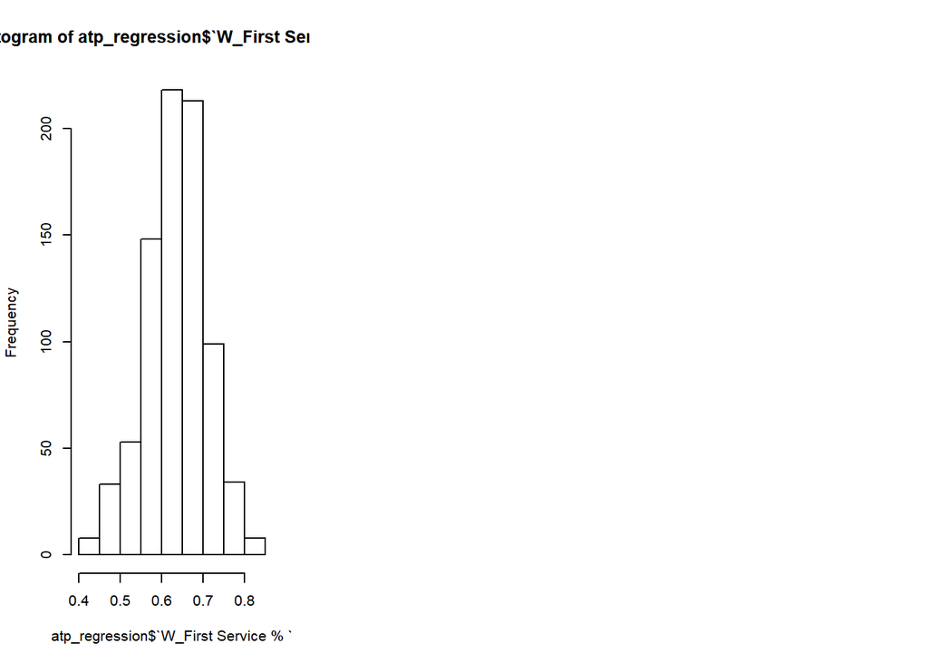

```r
hist(atp_regression$`W_First Service % `)

export_summs(reg_1, reg_2, reg_3, logreg_1)
```

Wenn man die abhängige Variable logarithmiert, ändert sich das Regressionsergebnis nur sehr minim. Dies liegt unter anderem daran, dass die abhängige Variable bereits sehr normalverteilt ist.

Nun wird dasselbe für die Verlierer gemacht.

```r
# Spalten umbenennen
colnames(atp_regression)[which(names(atp_regression) == "sentiment_mean.loser")] <- "sent_mean_loser_today"
colnames(atp_regression)[which(names(atp_regression) == "sentiment_twitter.loser")] <- "sent_tweet_loser_today"
colnames(atp_regression)[which(names(atp_regression) == "sentiment_instagram.loser")] <- "sent_insta_loser_today"

# Tabelle zuerst nach losername und dann nach Datum sortieren
atp_regression <- atp_regression[order(atp_regression[ ,1], -as.numeric(atp_regression[ ,2])), ]

# neue Spalten erstellen
atp_regression$sent_mean_loser_yesterday <- rep(NA, dim(atp_regression)[1])
atp_regression$sent_tweet_loser_yesterday <- rep(NA, dim(atp_regression)[1])
atp_regression$sent_insta_loser_yesterday <- rep(NA, dim(atp_regression)[1])

# Zeilen mit leeren Verlierername entfernen
atp_regression <- atp_regression[!is.na(atp_regression$loser_name), ]

# Neue Spalten mit den Sentiments vom Vortag erstellen
for (i in 1:(dim(atp_regression)[1] -1)) {
  if (atp_regression$loser_name[i] == atp_regression$loser_name[i+1]){

    if (atp_regression$match_dat[i] == atp_regression$match_dat[i+1] +1){

       atp_regression$sent_mean_loser_yesterday[i] <- atp_regression$sent_mean_loser_today[i + 1]
    }
  }
}

for (i in 1:(dim(atp_regression)[1] -1)) {
  if (atp_regression$loser_name[i] == atp_regression$loser_name[i+1]){

    if (atp_regression$match_dat[i] == atp_regression$match_dat[i+1] +1){

       atp_regression$sent_tweet_loser_yesterday[i] <- atp_regression$sent_tweet_loser_today[i + 1]
    }
  }
}

for (i in 1:(dim(atp_regression)[1] -1)) {
  if (atp_regression$loser_name[i] == atp_regression$loser_name[i+1]){

    if (atp_regression$match_dat[i] == atp_regression$match_dat[i+1] +1){

       atp_regression$sent_insta_loser_yesterday[i] <- atp_regression$sent_insta_loser_today[i + 1]
    }
  }
}
```

Im obigen Abschnitt wurde versucht eine Regression vom Sentiment vom Verlierer auf den First Serve vom Verlierer zu erstellen. Da der Fokus dieser Arbeit auf die Top 10 Tennisspieler liegt, enthält unser Datensatz zu wenig Information über die Sentimente der Verlierer. Somit ist keine Regression zwischen Sentiment Verlierer und 1st serve Verlierer möglich.

Nun erfolgt der gleiche Prozess mit den WTA Daten.

```r
# nur relevante Spalten in neue Tabelle kopieren
wta_regression <- wta_total[, c(1, 2, 3, 9, 31, 41, 50, 51, 52, 53, 54, 55)]
players = unique(wta_regression$winner_name)

# Spalten umbenennen
colnames(wta_regression)[which(names(wta_regression) == "sentiment_mean.winner")] <- "sent_mean_win_today"
colnames(wta_regression)[which(names(wta_regression) == "sentiment_twitter.winner")] <- "sent_tweet_win_today"
colnames(wta_regression)[which(names(wta_regression) == "sentiment_instagram.winner")] <- "sent_insta_win_today"

# Tabelle zuerst nach Gewinnername und dann nach Datum sortieren
wta_regression <- wta_regression[order(wta_regression[ ,3], -as.numeric(wta_regression[ ,2])), ]

# neue Spalten erstellen
wta_regression$sent_mean_win_yesterday <- rep(NA, dim(wta_regression)[1])
wta_regression$sent_tweet_win_yesterday <- rep(NA, dim(wta_regression)[1])
wta_regression$sent_insta_win_yesterday <- rep(NA, dim(wta_regression)[1])

# Zeilen mit leeren Datumsfelder entfernen
wta_regression <- wta_regression[!is.na(wta_regression$match_dat), ]

# Neue Spalten mit den Sentiments vom Vortag erstellen
for (i in 1:(dim(wta_regression)[1] -1)) {
  if (wta_regression$winner_name[i] == wta_regression$winner_name[i+1]){

    if (wta_regression$match_dat[i] == wta_regression$match_dat[i+1] +1){

       wta_regression$sent_mean_win_yesterday[i] <- wta_regression$sent_mean_win_today[i + 1]
    }
  }
}

for (i in 1:(dim(wta_regression)[1] -1)) {
  if (wta_regression$winner_name[i] == wta_regression$winner_name[i+1]){

    if (wta_regression$match_dat[i] == wta_regression$match_dat[i+1] +1){

       wta_regression$sent_tweet_win_yesterday[i] <- wta_regression$sent_tweet_win_today[i + 1]
    }
  }
}

for (i in 1:(dim(wta_regression)[1] -1)) {
  if (wta_regression$winner_name[i] == wta_regression$winner_name[i+1]){

    if (wta_regression$match_dat[i] == wta_regression$match_dat[i+1] +1){

       wta_regression$sent_insta_win_yesterday[i] <- wta_regression$sent_insta_win_today[i + 1]
    }
  }
}

par(mfrow=c(1,3)) # drei Graphen nebeneinander zu plotten

# Regression 5: Durchschnittssentiment vom Vortag von Gewinnerin auf Winner First serve
reg_5 =lm(wta_regression$`W_First Service % `~ wta_regression$sent_mean_win_yesterday, use="complete.obs")
summary(reg_5)
```

```
##
## Call:
## lm(formula = wta_regression$`W_First Service % ` ~ wta_regression$sent_mean_win_yesterday,
##     use = "complete.obs")
##
## Residuals:
##       Min        1Q    Median        3Q       Max
## -0.173103 -0.052475  0.002102  0.051271  0.243274
##
## Coefficients:
##                                        Estimate Std. Error t value
## (Intercept)                            0.621379   0.005337 116.418
## wta_regression$sent_mean_win_yesterday 0.001694   0.013318   0.127
##                                        Pr(>|t|)
## (Intercept)                              <2e-16 ***
## wta_regression$sent_mean_win_yesterday    0.899
## ---
## Signif. codes:  0 '***' 0.001 '**' 0.01 '*' 0.05 '.' 0.1 ' ' 1
##
## Residual standard error: 0.07601 on 296 degrees of freedom
##   (6168 observations deleted due to missingness)
## Multiple R-squared:  5.464e-05,  Adjusted R-squared:  -0.003324
## F-statistic: 0.01617 on 1 and 296 DF,  p-value: 0.8989
```

```r
plot_5 = plot(wta_regression$`W_First Service % `,wta_regression$sent_mean_win_yesterday, main = "Mean Sentiment Yesterday", ylab="Mean Sentiment Yesterday Winner",
              xlab = "Winner's First Service", col = "royalblue4", ylim=c(-3,4))
abline(reg_5, col = "red")

# Regression 6: Twittersentiment vom Vortag von Gewinnerin auf Winner First serve
reg_6 =lm(wta_regression$`W_First Service % `~wta_regression$sent_tweet_win_yesterday, use="complete.obs")
summary(reg_6)
```

```
##
## Call:
## lm(formula = wta_regression$`W_First Service % ` ~ wta_regression$sent_tweet_win_yesterday,
##     use = "complete.obs")
##
## Residuals:
##       Min        1Q    Median        3Q       Max
## -0.176066 -0.056255  0.003465  0.052448  0.239037
##
## Coefficients:
##                                         Estimate Std. Error t value
## (Intercept)                             0.623214   0.006422  97.047
## wta_regression$sent_tweet_win_yesterday 0.010456   0.019225   0.544
##                                         Pr(>|t|)
## (Intercept)                               <2e-16 ***
## wta_regression$sent_tweet_win_yesterday    0.587
## ---
## Signif. codes:  0 '***' 0.001 '**' 0.01 '*' 0.05 '.' 0.1 ' ' 1
##
## Residual standard error: 0.07866 on 220 degrees of freedom
##   (6244 observations deleted due to missingness)
## Multiple R-squared:  0.001343,   Adjusted R-squared:  -0.003197
## F-statistic: 0.2958 on 1 and 220 DF,  p-value: 0.5871
```

```r
plot_6 = plot(wta_regression$`W_First Service % `,wta_regression$sent_tweet_win_yesterday, main = "Twitter Sentiment Yesterday", ylab="Twitter Sentiment Yesterday Winner",
              xlab = "Winner's First Service", col = "royalblue4", ylim=c(-3,4))
abline(reg_6, col = "red")

# Regression 7: Instagramsentiment vom Vortag von Gewinnerin auf Winner First serve
reg_7 =lm(wta_regression$`W_First Service % `~wta_regression$sent_insta_win_yesterday, use="complete.obs")
summary(reg_7)
```

```
##
## Call:
## lm(formula = wta_regression$`W_First Service % ` ~ wta_regression$sent_insta_win_yesterday,
##     use = "complete.obs")
##
## Residuals:
##       Min        1Q    Median        3Q       Max
## -0.170959 -0.052736  0.002383  0.048128  0.245630
##
## Coefficients:
##                                         Estimate Std. Error t value
## (Intercept)                             0.619235   0.005992 103.341
## wta_regression$sent_insta_win_yesterday 0.005718   0.013145   0.435
##                                         Pr(>|t|)
## (Intercept)                               <2e-16 ***
## wta_regression$sent_insta_win_yesterday    0.664
## ---
## Signif. codes:  0 '***' 0.001 '**' 0.01 '*' 0.05 '.' 0.1 ' ' 1
##
## Residual standard error: 0.07535 on 232 degrees of freedom
##   (6232 observations deleted due to missingness)
## Multiple R-squared:  0.0008148,  Adjusted R-squared:  -0.003492
## F-statistic: 0.1892 on 1 and 232 DF,  p-value: 0.664
```

[figure not shown]

```r
plot_7 = plot(wta_regression$`W_First Service % `,wta_regression$sent_insta_win_yesterday, main = "Instagram Sentiment Yesterday", ylab="Instagram Sentiment Yesterday Winner",
              xlab = "Winner's First Service", col = "royalblue4", ylim=c(-3,4))
abline(reg_7, col = "red")
```

```r
export_summs(reg_5, reg_6, reg_7)
```

|  | Model 1 | Model 2 | Model 3 |
| --- | --- | --- | --- |
| (Intercept) | 0.62 *** | 0.62 *** | 0.62 *** |
|  | (0.01) | (0.01) | (0.01) |
| wta_regression$sent_mean_win_yesterday | 0.00 |  |  |
|  | (0.01) |  |  |
| wta_regression$sent_tweet_win_yesterday |  | 0.01 |  |
|  |  | (0.02) |  |
| wta_regression$sent_insta_win_yesterday |  |  | 0.01 |
|  |  |  | (0.01) |
| N | 298 | 222 | 234 |
| R2 | 0.00 | 0.00 | 0.00 |
| *** p < 0.001; ** p < 0.01; * p < 0.05. |  |  |  |